# NYPD_Analysis

S. Asuka

2023-10-26

# Overview

In this document, Analysis of NYPD shooting incidents is conducted. To see the big picture, time series analysis on the number of incidents and relation between the number of incidents and perpetrators race are conducted.

## Dataset

The data set contain data from 2006 to 2022 about shooting incidents happened in NY with attributes of Perpetrators and victims. Data set can be found here. And detail headers (columns) will be shown below. https://catalog.data.gov/dataset/nypd-shooting-incident-data-historic

## Structure

This documents consists of 4 parts; 1) preparation, 2) time series analysis, 3) analysis by race and 4) regression by race.

# Import library

As preparation, libraries and the data are imported

```r
library(ggplot2)
library(tidyverse)
library(lubridate)
library(mgcv)
```

## Import dataset

Data file came from; https://catalog.data.gov/dataset/nypd-shooting-incident-data-historic

```r
#df =read.csv("NYPD_Shooting_Incident_Data__Historic_.csv")
url = "https://data.cityofnewyork.us/api/views/833y-fsy8/rows.csv"
df = read.csv(url)
df$OCCUR_DATE =  as.Date(as.character(df$OCCUR_DATE), format="%m/%d/%Y")
head(df,1)
```

```
##   INCIDENT_KEY OCCUR_DATE OCCUR_TIME   BORO LOC_OF_OCCUR_DESC PRECINCT
## 1    228798151 2021-05-27   21:30:00 QUEENS                        105
##   JURISDICTION_CODE LOC_CLASSFCTN_DESC LOCATION_DESC STATISTICAL_MURDER_FLAG
## 1                 0                                                    false
##   PERP_AGE_GROUP PERP_SEX PERP_RACE VIC_AGE_GROUP VIC_SEX VIC_RACE X_COORD_CD
## 1                                           18-24       M    BLACK    1058925
##   Y_COORD_CD Latitude Longitude                                       Lon_Lat
## 1     180924 40.66296 -73.73084 POINT (-73.73083868899994 40.662964620000025)
```

# Focus on insident trend by year

The trend of the number of incidents are analyzed. Grouping by Year and flag that murdered or not, the trend is plotted

```r
#group_by(year,BORO,STATISTICAL_MURDER_FLAG,PERP_AGE_GROUP,PERP_SEX,PERP_RACE,VIC_AGE_GROUP,VIC_SEX,VIC_RACE) %>%
df.gb = df %>%
    mutate(year = floor_date(OCCUR_DATE, "year")) %>%
        group_by(year,STATISTICAL_MURDER_FLAG,,PERP_RACE) %>%
    summarise(INCIDENT_KEY = n())
head(df.gb)
```

```
## # A tibble: 6 × 4
## # Groups:   year, STATISTICAL_MURDER_FLAG [1]
##   year       STATISTICAL_MURDER_FLAG PERP_RACE                  INCIDENT_KEY
##   <date>     <chr>                   <chr>                             <int>
## 1 2006-01-01 false                   ""                                   81
## 2 2006-01-01 false                   "ASIAN / PACIFIC ISLANDER"            2
## 3 2006-01-01 false                   "BLACK"                             948
## 4 2006-01-01 false                   "BLACK HISPANIC"                     67
## 5 2006-01-01 false                   "UNKNOWN"                           322
## 6 2006-01-01 false                   "WHITE"                              20
```

# Plotting dataset

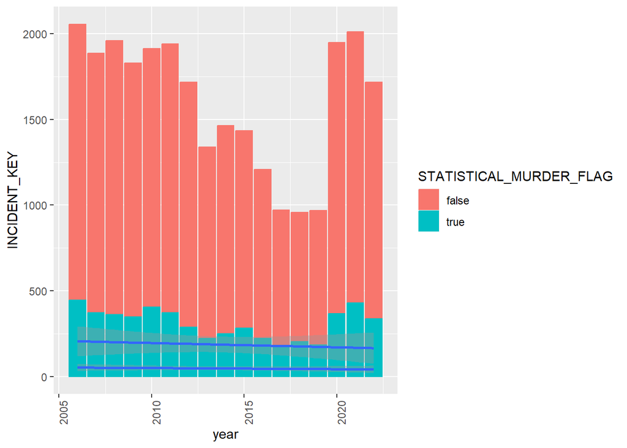

```r
ggplot(df.gb, aes(x=year,y =INCIDENT_KEY, group=STATISTICAL_MURDER_FLAG),color= STATISTICAL_MURDER_FLAG)+
      geom_bar(aes( color= STATISTICAL_MURDER_FLAG, fill = STATISTICAL_MURDER_FLAG), stat = "identity",  position = "stack", show.legend = T) +
    geom_smooth(method="lm") +
    theme(axis.text.x = element_text(angle = 90))
```

# Interpretation of the graph

The number of incidents decreased from 2006 to 2016 and became stable by 2019. From 2020, it increased again. True (murder) moved relatively moderately compared to false (non-murder) incidents.

# Insident by Race

Secondly, relation between the number of incidents and perpetrator race is analyzed. Using a boxing plot, the mean and distribution for each race is observed.

```r
#group_by(year,BORO,STATISTICAL_MURDER_FLAG,PERP_AGE_GROUP,PERP_SEX,PERP_RACE,VIC_AGE_GROUP,VIC_SEX,VIC_RACE) %>%
df.gb2 = df %>%
    mutate(year = floor_date(OCCUR_DATE, "year")) %>%
        group_by(year,PERP_RACE) %>%
    summarise(INCIDENT_KEY = n())
head(df.gb2,10)
```

```
## # A tibble: 10 × 3
## # Groups:   year [2]
##    year       PERP_RACE                  INCIDENT_KEY
##    <date>     <chr>                             <int>
##  1 2006-01-01 ""                                  131
##  2 2006-01-01 "ASIAN / PACIFIC ISLANDER"            6
##  3 2006-01-01 "BLACK"                            1178
##  4 2006-01-01 "BLACK HISPANIC"                     90
##  5 2006-01-01 "UNKNOWN"                           400
##  6 2006-01-01 "WHITE"                              28
##  7 2006-01-01 "WHITE HISPANIC"                    222
##  8 2007-01-01 ""                                  281
##  9 2007-01-01 "ASIAN / PACIFIC ISLANDER"           10
## 10 2007-01-01 "BLACK"                            1018
```

```r
df.gb2  = df.gb2 %>%
    mutate(PERP_RACE = fct_recode(PERP_RACE,
                           "AS/PA" = "ASIAN / PACIFIC ISLANDER",
                            "BL" = "BLACK",
                             "BLHI" ="BLACK HISPANIC",
                                  "WHHI" ="WHITE HISPANIC",
                           "WH" = "WHITE",
                                  "AI/AN" = "AMERICAN INDIAN/ALASKAN NATIVE",
                           "AS" = "ASIANS"
                          ))
```

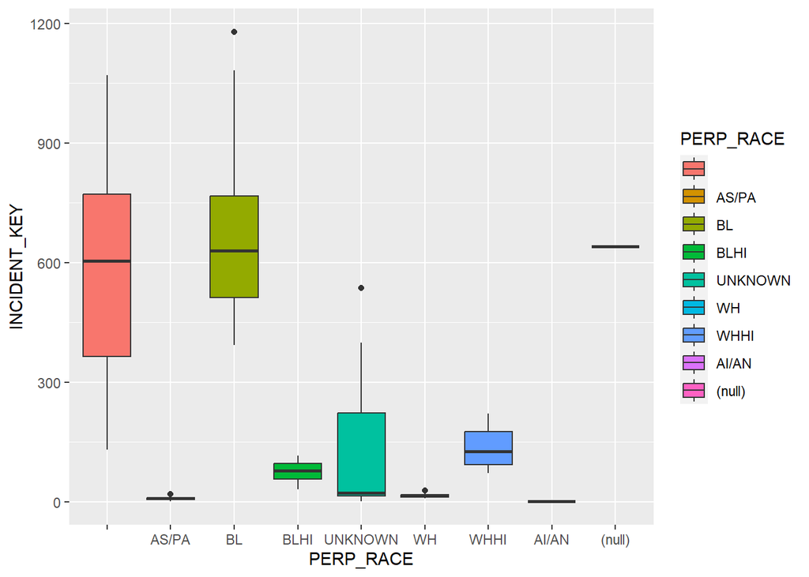

```r
ggplot(data = df.gb2,
       mapping = aes(x=PERP_RACE,
                     y=INCIDENT_KEY,
                     fill=PERP_RACE)) +
  geom_boxplot()
```

# Interpretation of the graph.

The number of incidents was largest for Black, followed by White Hispanic and Black Hispanic, when “unknown/NA” are ignored. These results don’t necessarily mean that people belonging to these races are more likely to cause issues. The data may contain certain biases, as people do. Also, the number of people living in the area, or other attributes like economic status, are not considered in this graph.